None

# Challenge

Although the root locus is helpful to visualize the possible location of poles and zeros for different gain values, understanding some simple sketching rules will allow you to rapdily explain an observed behavior (e.g. "why the heck is my system oscillating like that !?!?) as well as make informed design decisions (e.g. "You should increase your Kd if you want to increase the damping of that closed loop system").

Your challenge is to become familiar enough with these sketching rules so that when you are working on real systems (say... a small robot capable of autonomous control) you will be able to interpret observed behavior AND make informed decisions on how to improve your controller to achived the desired result.

# Root Locus Overview

The root locus is a plot on the complex plane of how each of the *closed loop* poles of a feedback control system move around the complex plane when one real, positive parameter $K$ in the forward path changes. **All you will need to use and understand root locus will be provided in these notebooks**, however root locus analysis is also covered in Schaum's Outline of Feedback and Control Systems, and in Dynamic Modeling and Control of Engineering systems, so you may wish to look there (or externally, e.g. YouTube, or even the control systems [wikibook](https://en.wikibooks.org/wiki/Control_Systems/Root_Locus)) for a more in-depth treatment.

# Disciplined Process: Root Locus sketching steps 1-4

To reiterate, we're talking about drawing the root locus of this system:

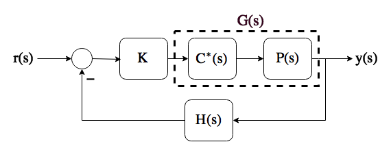

Which has the closed loop transfer function $G_{cl}(s) = \frac{y(s)}{r(s)}=\frac{KG}{1+KGH}$. We'll following the following steps to generate a sketch. In particular, we'll talk about steps 3 and 4, since 1 and 2 are fairly straightforward.

**While you are learning to draw a root locus, you can use Octave/MATLAB to help you check your work by using the "rlocus" command, which takes the 'open loop transfer function' G(s)H(s) as its argument.**

## Step 1: Find the Closed loop characteristic equation for your system:

$$1+KG(s)H(s)=0$$

## Step 2: Write the Closed loop characteristic equation as

$$\frac{-1}{K}=G(s)H(s)$$

## Step 3: Identify segments of the root locus on the real axis

This step is a direct result of the angle criterion (actually, pretty much all of the steps are as well!). If I plot the following root loci using MATLAB, you'll notice that the root locus lies on the real axis only when I can find an **odd number** of poles and/or zeros of the open loop transfer function $G(s)H(s)$ to the **right** of that portion of the real axis.

[output not shown]

[output cut: 71 more lines]

[output not shown]

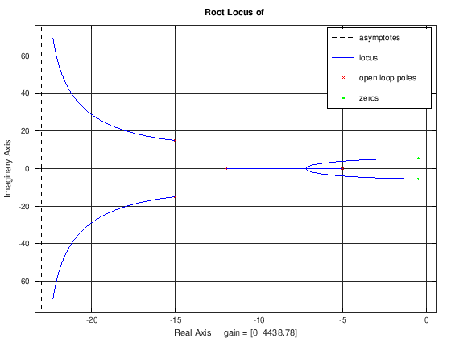

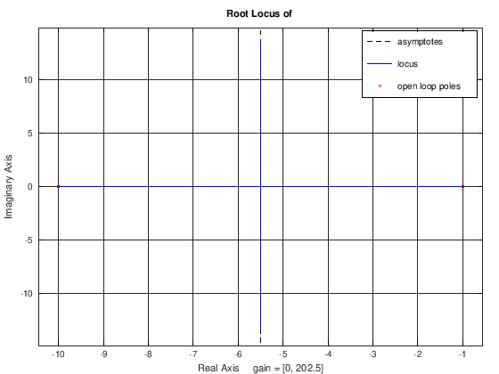

[figure not shown]

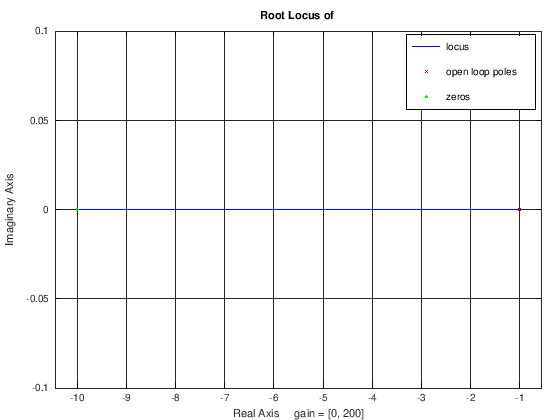

```matlab
s = tf('s');

figure
rlocus(1/((s+1)*(s+2)*(s+3)*(s+4)*(s+5)*(s+6)));
figure
rlocus((s^2+s+30)/((s+5)*(s+12)*(s^2+30*s+450)));
figure
rlocus(1/((s+1)*(s+10)));
figure
rlocus((s+10)/(s+1));
```

This is also a good time to notice that **The root locus is always symmetrical about the real axis**. This is because poles of the closed loop system always come in complex conjugate pairs. But back to the task at hand, it is easiest to see why this "odd number" rule is true if we look at a system that only has real poles and zeros. Let's assume we have an "open loop" transfer function with a pole-zero map this one, where "o" represents a zero of $G(s)H(s)$ and "x" represents a pole of $G(s)H(s)$:

[figure not shown]

For the sake of argument, let's say that this system has an open loop transfer function $G(s)H(s) = \frac{s+1}{(s+2)(s+4)}$. Remember that under feedback control with some varying, real, positive parameter $K$, we can write the characteristic equation as:

$$\frac{-1}{K}=G(s)H(s)$$

Remember as well that $\frac{-1}{K}$ will always have an angle of $\pm 180^\circ$... in other words, $G(s)H(s)$ must always be a negative real number if a "trial point" $s=s_1$ is "on the root locus."

So let's test a point $s_1=-0.5$. Substituting into $G(s)H(s)$ gives us:

$$ G(-.5)H(-.5) = \frac{.5}{(1.5)(3.5)}$$

Which is not a negative real number, and is thus not on the root locus. Now, let's test a trial point $s_2 = -1.5$, which gives us:

$$G(-1.5)H(-1.5) = \frac{-.5}{(.5)(2.5)}$$

which is not a negative, real number, and thus does not have an angle on the complex plane of $\pm 180^\circ$. Of course, that means that the point (and all others between -2 and -4-- check for yourself!) is not on the root locus. However, if we check points to the left of -4, we'll find that the root locus lies on the real axis again.

### Summary

The root locus lies **on a portion of the real axis** if and only if there is an **odd number of open loop poles and zeros to the right of that portion on the s-plane**.

## Step 4: Identify the angle(s) of any asymptotes on the root locus and find the point at which the asymptotes intersect

You will notice that 3 of the 4 root loci I plotted in the previous section showed at least one branch of the root locus ( a branch is the path of one of the closed loop poles) shooting off towards infinity as the gain factor $K$ gets large. The reason this happens is simple, and is actually best described by the magnitude criterion of the root locus. Recall that the closed loop characteristic equation is:

$$\frac{-1}{K}=G(s)H(s)$$

so if $K\rightarrow \infty$, the magnitude of the left-hand side of the equation goes to zero, which means that the magnitude of the right hand side of the equation must also go to zero. In order for this to happen, one of two things must be true:

1. The value of $s$ is equal to one of the zeros of $G(s)H(s)$
2. The magnitude of $s$ is $\infty$.

Conversely, we can use the same logic to confirm that at $K=0$, the root locus begins at the open-loop poles (the poles of $G(s)H(s)$, because $\left|\frac{-1}{K}\right|=\left|G(s)H(s)\right|=\left|\frac{-1}{0}\right|=\infty$ is only satisfied when $s$ is equal to one of the poles of $G(s)H(s)$

This leads us to the following "rules" of root locus construction:

- Each branch of the root locus begins at one of the poles of $G(s)H(s)$
- Each branch of the root locus ends either at one of the zeros of $G(s)H(s)$ or at infinity.
- Based on the previous rule, we know that the number of "asymptotes" on the root locus is equal to the number of poles of $G(s)H(s)$ minus the number of zeros of $G(s)H(s)$. This is often written: $$a = n-m$$ Where "a" is the number of asymptotes, "n" is the number of poles of $G(S)H(s)$, and "m" is the number of zeros of $G(s)H(s)$.

Further, each asymptote has a an angle with respect to the positive real axis, and all of the asymptotes of the root locus will intersect at one point on the real axis of the s-plane. The proof of this is not given here, but the point of intersection and the angle of the asymptotes can be found using the following equations:

To find the point of intersection of all asymptotes, find:

$$\sigma_a = \frac{\sum poles -\sum zeros}{n-m}$$

To find the angle of each asymptote, compute the following for $k=0,\ldots,a-1$

$$\theta_a = \frac{2k+1}{n-m}\pi$$

## Example

Let's try computing the segments of the root locus and the angles of the asymptotes of the root locus branches this for a classic third-order system, with $G(s)H(s) = \frac{1}{(s+1)(s+2)(s+3)}$. We will go through the sketching steps 1 through 4.

### Step 1

We find that $1+\frac{1}{(s+1)(s+2)(s+3)}=0$

### Step 2

We can then write $\frac{-1}{K} = \frac{1}{(s+1)(s+2)(s+3)}$

### Step 3

Now, we'd like to find segments of the root locus that lie on the real axis and show them on our sketch. First, let's plot the open loop poles and zeros:

[figure not shown]

Now, we sketch the root locus as being on the real axis wherever we find an odd number of poles and zeros of $G(s)H(s)$ to the right of that portion of the real axis as follows:

[figure not shown]

### Step 4

Now our job is to find asymptotes, their intersection point, and their angles. We know that the two branches that started at s=-1 and s=-2 can't stay on the real axis forever... there are no zeros, so the number of asymptotes we expect from the plot is

$$a = n-m=3-0$$

So we need to find 3 asymptotes. It looks like we've already found 1 of them using step 3... to the left of s=-3, there are always 3 open loop poles to our right, so the root locus is always on the root locus there. But what happens to the two branches that originated at s=-1 and s=-2? They must somehow to to infinity on the complex plane, and they'll do this by "breaking away" from the real axis somewhere between -2 and -1. The angles of the 3 asymptotes for our system are given by:

$$\theta_a = \frac{2k+1}{n-m}\pi$$

Which we evaluate for k=0, 1, and 2. This gives us the following three asymptote angles:

For k = 0, we get: $$\theta_1 = \frac{1}{3}\pi$$

For k=1, we get: $$\theta_2 = \frac{3}{3}\pi$$

And for k=2, we get: $$\theta_3 = \frac{5}{3}\pi$$

These asymptotes all meet at one place on the real axis. This place is found by computing:

$$\sigma_a = \frac{\sum poles -\sum zeros}{n-m} = \frac{(-1)+(-2)+(-3)}{3} = -2$$

So the asymptotes are at $60^\circ$, $180^\circ$ (which we already found using step 3), and $300^\circ$, and they meet at $s=-2$. Let's draw these asymptotes on our root locus sketch:

[figure not shown]

Now, we know that the locus has to "break away" from the real axis to approach these asymptotes, and that it must do this between s=-1 and s=-2 somewhere. We don't know how to calculate exactly where this happens yet (that's step 5), but for now, we'll just pick a point somewhere in between s=-1 and s=-2, and draw the two branches approaching their respective asymptotes to complete our sketch. We'll learn how to calculate the break-away and break-in points in the next reading assignment.

[figure not shown]

So this concludes our sketch. The "exercises" notebook includes some practice problems for you to try on your own. As always, you can check the validity of your hand-sketch by using the "rlocus" command:

[output not shown]

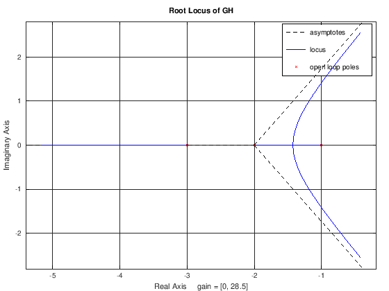

```matlab
s = tf('s');

GH = 1/((s+1)*(s+2)*(s+3))
rlocus(GH)
```

As you can see, our sketch matches fairly well!! The other thing that's important to note about this system is that at some value of $K$, it goes unstable under feedback control!! This is really important to realize... especially given the fact that we often "ignore" faster poles in our modeling efforts using the separation principle. What this root locus sketch tells us is that the ignoring fast poles get less and less trustworthy if I use a large-gain feedback controller on the plant $P(s)$. Exactly what gain causes instability for a particular system is the subject of a later root locus sketching step, which we will cover shortly.

# Summary of Root Locus Properties

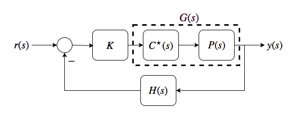

1. The characteristic equation for this system is $1+KG(s)H(s)=0$, which can be rewritten as $-\frac{1}{K}=G(s)H(s)$.
2. The location of each possible pole is governed by the *angle criterion* for the root locus: $\angle -\frac{1}{K}=\angle G(s)H(s) = \pm 180^\circ$.
3. There are exactly as many **branches** (paths for a closed loop pole to follow) as the number of **poles in G(s)H(s)**.
4. When $K=0$, the closed loop poles lie at **the poles of the 'open loop transfer function' G(s)H(s)** because of the magnitude criterion: $\left|-\frac{1}{K}\right| = \infty = \left|G(s)H(s)\right|$. The only way to make $G(s)H(s)=\infty$ is to set $s$ to one of the poles of $G(s)H(s)$.
5. When $K=\infty$, the closed loop poles go to **either** a **zero** of $G(s)H(s)$ or infinity. This is because of the magnitude criterion. The fraction $\left|-\frac{1}{K}\right|=0= \left| G(s)H(s)\right|$. There are two ways to make $G(s)H(s)=0$. One is that $s$ is one of the **zeros** of G(s)H(s), and the other is that the magnitude of $s$ goes to infinity. Assuming that the transfer function is strictly proper (meaning that at least one branch of the root locus goes to infinity), setting the magnitude of $s$ to infinity will make the transfer function's magnitude go to zero.
6. If a branch goes to infinity, it does so along an *asymptote*.
7. A branch will lie on a portion of the real axis if there is an odd number of poles and zeros of $G(s)H(s)$ to the *right* of that portion. This is required by the angle criterion.
8. The root locus branches can "break away" from and "break in" to the real axis. They always do so perpendicularly to the real axis. This is required by the angle criterion.
9. The root locus is always symmetrical about the real axis. This is required by the angle criterion.

# Disciplined Process: Root locus steps 1-4 summary

1. Find the Closed loop characteristic equation for your system: $$1+KG(s)H(s)=0$$
2. Write the Closed loop characteristic equation as $$\frac{-1}{K}=G(s)H(s)$$
1. Plot the poles and zeros of $G(s)H(s)$ on the s-plane. Identify any segments of the root locus on the real axis: the root locus lies on a portion of the real axis if and only if an *odd* number of "open loop" poles and zeros (poles and zeros of $G(s)H(s)$ are to the *right* of that portion of the real axis.
1. Identify the angle(s) of any asymptotes and the point on the real axis where the asymptotes intersect: $$\sigma_a = \frac{\sum poles -\sum zeros}{n-m}$$ $$\theta_a = \frac{2k+1}{n-m}\pi$$

Finally, use the asymptotes to sketch each branch (one per pole of $G(s)H(s)$) of your system's root locus, noting that each pole of the closed loop system will begin at one of the poles of $G(s)H(s)$ and terminate at either a zero of $G(s)H(s)$ or at infinity.

**NOTE! There are more steps to come!**

# Exercises Due MONDAY, October 5 by MIDNIGHT

Based on steps 1-4 of the root locus sketching guidelines, create a hand sketch for each of the following systems. Include any hand calculations you perform, and include your hand-sketch of the locus. Remember that you can always check the accuracy of your hand-sketch using the "rlocus" command.

## Exercise 1

Sketch the root locus for $G(s)H(s) = \frac{1}{s^2+s+10}$ using only steps 1-4 of the guidelines. Put your hand sketch **and relevant calculations** in the markdown cell. Verify your work using the code cell below using either MATLAB or Octave as the notebook kernel.

```matlab
% YOUR CODE HERE
error('No Answer Given!')
```

```
error: No Answer Given!
```

## Exercise 2

Sketch the root locus for $G(s)H(s) = \frac{s+4}{(s+1)(s+10)}$ using only steps 1-4 of the guidelines. Put your hand sketch **and relevant calculations** in the markdown cell. Verify your work using the code cell below using either MATLAB or Octave as the notebook kernel.

```matlab
% YOUR CODE HERE
error('No Answer Given!')
```

```
error: No Answer Given!
```

## Exercise 3

Sketch the root locus for $G(s)H(s) = \frac{1}{(s^2+10s+300)(s+1)(s+2)}$ using only steps 1-4 of the guidelines. Put your hand sketch **and relevant calculations** in the markdown cell. Verify your work using the code cell below using either MATLAB or Octave as the notebook kernel.

```matlab
% YOUR CODE HERE
error('No Answer Given!')
```

```
error: No Answer Given!
```